# Bicycle Data Wrangling

Scott Burstein

2020-09-01

## Clone a repo + start a new project

Go to the `ae04-[GITHUB USERNAME]` repo, clone it, and start a new project in RStudio. See previous labs and application exercises for more detailed instructions about cloning a repo and starting a project.

### Configure git

Run the following code to configure Git. Fill in your GitHub username and the email address associated with your GitHub account.

```r
library(usethis)
use_git_config(user.name= "sburstein", user.email="scott.burstein@duke.edu")
```

## Practice with data wrangling

```r
library(tidyverse)
```

The data set contains all North Carolina bike crash data from 2007-2014. The data was originally downloaded on September 6, 2018 and is available in the dsbox R package.

Use the code below to load the data from the .csv file

```r
ncbikecrash <- read_csv("data/ncbikecrash.csv")
```

### Part 1

**Display the first 10 rows of the ncbikecrash data set.**

```r
ncbikecrash %>%
  slice(1:10)
```

```
## # A tibble: 10 x 66
##    object_id city  county region development locality on_road rural_urban
##        <dbl> <chr> <chr>  <chr>  <chr>       <chr>    <chr>   <chr>
##  1      1686 None… Wayne  Coast… Farms, Woo… Rural (… SR 1915 Rural
##  2      1674 Hend… Vance  Piedm… Residential Mixed (… NICHOL… Urban
##  3      1673 None… Linco… Piedm… Farms, Woo… Rural (… US 321  Rural
##  4      1687 Whit… Colum… Coast… Commercial  Urban (… W BURK… Urban
##  5      1653 Wilm… New H… Coast… Residential Urban (… RACINE… Urban
##  6      1665 None… Robes… Coast… Farms, Woo… Rural (… SR 1513 Rural
##  7      1642 None… Richm… Piedm… Residential Mixed (… SR 1903 Rural
##  8      1675 Rale… Wake   Piedm… Commercial  Urban (… PERSON… Urban
##  9      1668 Whit… Colum… Coast… Residential Rural (… FLOWER… Urban
## 10      1662 New … Craven Coast… Residential Urban (… SUTTON… Urban
## # … with 58 more variables: speed_limit <chr>, traffic_control <chr>,
## #   weather <chr>, workzone <chr>, bike_age <chr>, bike_age_group <chr>,
## #   bike_alcohol <chr>, bike_alcohol_drugs <chr>, bike_direction <chr>,
## #   bike_injury <chr>, bike_position <chr>, bike_race <chr>, bike_sex <chr>,
## #   driver_age <chr>, driver_age_group <chr>, driver_alcohol <chr>,
## #   driver_alcohol_drugs <chr>, driver_est_speed <chr>, driver_injury <chr>,
## #   driver_race <chr>, driver_sex <chr>, driver_vehicle_type <chr>,
## #   crash_alcohol <chr>, crash_date <chr>, crash_day <chr>, crash_group <chr>,
## #   crash_hour <dbl>, crash_location <chr>, crash_month <chr>,
## #   crash_severity <chr>, crash_time <time>, crash_type <chr>,
## #   crash_year <dbl>, ambulance_req <chr>, hit_run <chr>,
## #   light_condition <chr>, road_character <chr>, road_class <chr>,
## #   road_condition <chr>, road_configuration <chr>, road_defects <chr>,
## #   road_feature <chr>, road_surface <chr>, num_bikes_ai <dbl>,
## #   num_bikes_bi <dbl>, num_bikes_ci <dbl>, num_bikes_ki <dbl>,
## #   num_bikes_no <dbl>, num_bikes_to <dbl>, num_bikes_ui <dbl>,
## #   num_lanes <chr>, num_units <dbl>, distance_mi_from <dbl>, frm_road <chr>,
## #   rte_invd_cd <dbl>, towrd_road <chr>, geo_point <chr>, geo_shape <chr>
```

### Part 2

**Filter for bike crashes in Durham County where the driver age group is 0 to 19.**

```r
ncbikecrash %>%
  filter(driver_age_group == "0-19", county == "Durham")
```

```
## # A tibble: 11 x 66
##    object_id city  county region development locality on_road rural_urban
##        <dbl> <chr> <chr>  <chr>  <chr>       <chr>    <chr>   <chr>
##  1      2431 Durh… Durham Piedm… Residential Urban (… <NA>    Urban
##  2       977 Durh… Durham Piedm… Residential Urban (… PP RIP… Urban
##  3      3321 Durh… Durham Piedm… Residential Urban (… <NA>    Urban
##  4      3355 Durh… Durham Piedm… Residential Mixed (… <NA>    Urban
##  5      4106 Durh… Durham Piedm… Residential Urban (… <NA>    Urban
##  6      1613 Durh… Durham Piedm… Residential Urban (… CECIL … Urban
##  7      3013 None… Durham Piedm… Commercial  Urban (… <NA>    Rural
##  8      5511 Durh… Durham Piedm… Commercial  Urban (… <NA>    Urban
##  9      6514 Durh… Durham Piedm… Residential Urban (… <NA>    Urban
## 10      3316 Durh… Durham Piedm… Residential Urban (… <NA>    Urban
## 11      5060 Durh… Durham Piedm… Commercial  Urban (… <NA>    Urban
## # … with 58 more variables: speed_limit <chr>, traffic_control <chr>,
## #   weather <chr>, workzone <chr>, bike_age <chr>, bike_age_group <chr>,
## #   bike_alcohol <chr>, bike_alcohol_drugs <chr>, bike_direction <chr>,
## #   bike_injury <chr>, bike_position <chr>, bike_race <chr>, bike_sex <chr>,
## #   driver_age <chr>, driver_age_group <chr>, driver_alcohol <chr>,
## #   driver_alcohol_drugs <chr>, driver_est_speed <chr>, driver_injury <chr>,
## #   driver_race <chr>, driver_sex <chr>, driver_vehicle_type <chr>,
## #   crash_alcohol <chr>, crash_date <chr>, crash_day <chr>, crash_group <chr>,
## #   crash_hour <dbl>, crash_location <chr>, crash_month <chr>,
## #   crash_severity <chr>, crash_time <time>, crash_type <chr>,
## #   crash_year <dbl>, ambulance_req <chr>, hit_run <chr>,
## #   light_condition <chr>, road_character <chr>, road_class <chr>,
## #   road_condition <chr>, road_configuration <chr>, road_defects <chr>,
## #   road_feature <chr>, road_surface <chr>, num_bikes_ai <dbl>,
## #   num_bikes_bi <dbl>, num_bikes_ci <dbl>, num_bikes_ki <dbl>,
## #   num_bikes_no <dbl>, num_bikes_to <dbl>, num_bikes_ui <dbl>,
## #   num_lanes <chr>, num_units <dbl>, distance_mi_from <dbl>, frm_road <chr>,
## #   rte_invd_cd <dbl>, towrd_road <chr>, geo_point <chr>, geo_shape <chr>
```

### Part 3

**On which day of the week did the most bike crashes occur? Use the `count` function to get the number of bike crashes for each day (`crash_day`). Display the results in descending order.**

```r
ncbikecrash %>%
  count(crash_day, sort = TRUE)
```

```
## # A tibble: 7 x 2
##   crash_day     n
##   <chr>     <int>
## 1 Friday     1179
## 2 Thursday   1148
## 3 Wednesday  1133
## 4 Tuesday    1130
## 5 Monday     1068
## 6 Saturday    988
## 7 Sunday      821
```

### Part 4

**Calculate the proportion of crashes that are hit and run (`hit_run`) for each hour (`crash_hour`)**

```r
ncbikecrash %>%
  group_by(crash_hour) %>%
  summarize(prop_hitrun = mean(hit_run == "Yes"))
```

```
## # A tibble: 24 x 2
##    crash_hour prop_hitrun
##         <dbl>       <dbl>
##  1          0      0.253
##  2          1      0.404
##  3          2      0.459
##  4          3      0.333
##  5          4      0.292
##  6          5      0.25
##  7          6      0.184
##  8          7      0.0537
##  9          8      0.0996
## 10          9      0.118
## # … with 14 more rows
```

### Part 5: Just for fun!

**Construct an effective visualization of the data from part 4**

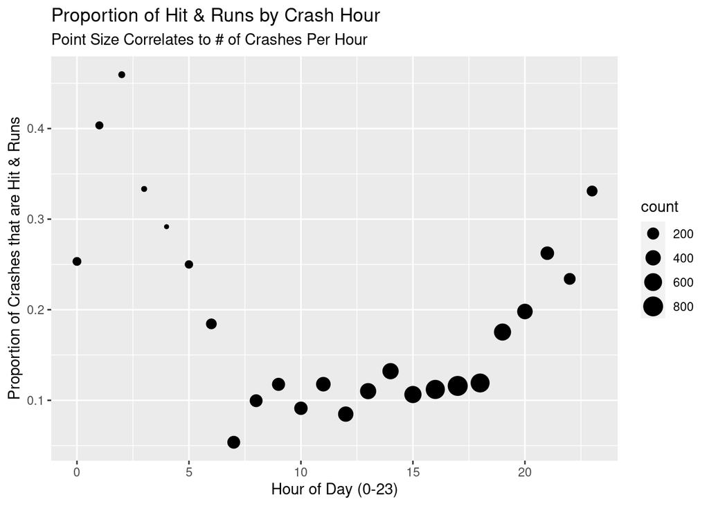

```r
ncbikecrash %>%
  group_by(crash_hour) %>%
  summarize(prop_hitrun = mean(hit_run == "Yes"),
            count = n()) %>%
  ggplot(mapping = aes(x = crash_hour, y = prop_hitrun)) +
  geom_point(aes(size = count)) +
  labs(title = "Proportion of Hit & Runs by Crash Hour",
       subtitle = "Point Size Correlates to # of Crashes Per Hour",
       x = "Hour of Day (0-23)",
       y = "Proportion of Crashes that are Hit & Runs")
```